# Project-1

## Problem Statement

Individuals are different and exhibit diverse behaviors, however a general prediction model could be used to asses one's behavior. Global financial crisis of 2007-2008 is greatly considered as a result of subprime mortgage loans in the United States. In addition, a huge amount of credit card payments goes pending every month in the US. While credit card debt has increase around 32% in the last five years. Therefore, to avoid future banking crisis, it is important to devise a mechanism that can predict the credit card behavior of the potential user.

## Data Description

In this research I will use an open source dataset 'The National Financial Capability Study' (NFCS) provided by FINRA. This dataset is a primary data collected from the US citizens with an interval of three years. The first round of survey was conducted in the year of 2009 following the Global financial turmoil. Later on, second round was conducted in 2012, third in 2015 and most recent survey was conducted in 2018. More detail of the dataset can be found [here](https://www.usfinancialcapability.org/) and can be downloaded [here](https://www.usfinancialcapability.org/downloads.php). This dataset includes a wide range of financial, demographic and professional indicators of American Citizens from all the regions and states.

```python
##Importing libraries
from sklearn.preprocessing import StandardScaler
import matplotlib.pyplot as plt
import pandas as pd
import numpy as np

%matplotlib inline
```

```python
#path ='/Users/rizwanmushtaq/Desktop/NFCS.csv'
df = pd.read_csv('NFCS.csv', dtype= 'unicode', decimal=',')
```

```python
#explore the number of columns and rows in the data
print(df.shape)
```

```
(108310, 112)
```

```python
print(df.head())
```

```
  TRACK      NFCSID STATEQ CENSUSDIV CENSUSREG A3 A3Ar_w A3B A4A_new_w  \
0  2018  2018010001     48         9         4  2      5  11         1
1  2018  2018010002     10         5         3  2      2   8         1
2  2018  2018010003     44         7         3  2      2   8         1
3  2018  2018010004     10         5         3  2      1   7         1
4  2018  2018010005     13         8         4  1      2   2         1

  A5_2015  ... M21_4  M6  M7  M8 M31  M9 M10      wgt_n2      wgt_d2  \
0       5  ...         1   3  98  98  98   1  0.68368306  0.51964208
1       6  ...         1   3  98   3   1  98  0.80835753  2.51684077
2       6  ...         1   1  98  98   1  98  1.02155141  1.89619186
3       6  ...        98  98   4   4   2  98  0.80835753  2.51684077
4       6  ...         1   3  98   2   1  98   0.4480747  0.61473322

       wgt_s3
0  1.09518877
1  0.92269329
2  0.67109295
3  0.92269329
4  1.23222123

[5 rows x 112 columns]
```

```python
#Renaming required columns
df = df.rename(columns={'A3':'gender','A3Ar_w':'agegrp','A4A_new_w': 'ethn', 'A5_2015':'edu' , 'A6':'marital' ,
      'A8':'hhincome',  'AM31':'retired' , 'A9':'prof', 'A22_2015':'currentstudent', 'M6':'interest', 'M7':'inflation',  'M8':'bond', 'M31':'cinterest', 'M9':'mortgage', 'M10':'risk',
     'J32':'creditrecord', 'G20':'unpaidbil'}, errors="raise")
```

```python
df.head()
```

|  | TRACK | NFCSID | STATEQ | CENSUSDIV | CENSUSREG | gender | agegrp | A3B | ethn | edu | ... | M21_4 | interest | inflation | bond | cinterest | mortgage | risk | wgt_n2 | wgt_d2 | wgt_s3 |
| --- | --- | --- | --- | --- | --- | --- | --- | --- | --- | --- | --- | --- | --- | --- | --- | --- | --- | --- | --- | --- | --- |
| 0 | 2018 | 2018010001 | 48 | 9 | 4 | 2 | 5 | 11 | 1 | 5 | ... |  | 1 | 3 | 98 | 98 | 98 | 1 | 0.68368306 | 0.51964208 | 1.09518877 |
| 1 | 2018 | 2018010002 | 10 | 5 | 3 | 2 | 2 | 8 | 1 | 6 | ... |  | 1 | 3 | 98 | 3 | 1 | 98 | 0.80835753 | 2.51684077 | 0.92269329 |
| 2 | 2018 | 2018010003 | 44 | 7 | 3 | 2 | 2 | 8 | 1 | 6 | ... |  | 1 | 1 | 98 | 98 | 1 | 98 | 1.02155141 | 1.89619186 | 0.67109295 |
| 3 | 2018 | 2018010004 | 10 | 5 | 3 | 2 | 1 | 7 | 1 | 6 | ... |  | 98 | 98 | 4 | 4 | 2 | 98 | 0.80835753 | 2.51684077 | 0.92269329 |
| 4 | 2018 | 2018010005 | 13 | 8 | 4 | 1 | 2 | 2 | 1 | 6 | ... |  | 1 | 3 | 98 | 2 | 1 | 98 | 0.4480747 | 0.61473322 | 1.23222123 |

5 rows × 112 columns

```python
#Selecting required columns
df = df[['gender', 'agegrp', 'ethn', 'edu' , 'marital', 'hhincome', 'retired', 'prof',
         'currentstudent', 'creditrecord', 'unpaidbil' ]]
```

```python
df.head()
```

|  | gender | agegrp | ethn | edu | marital | hhincome | retired | prof | currentstudent | creditrecord | unpaidbil |
| --- | --- | --- | --- | --- | --- | --- | --- | --- | --- | --- | --- |
| 0 | 2 | 5 | 1 | 5 | 4 | 1 |  | 6 |  | 1 | 2 |
| 1 | 2 | 2 | 1 | 6 | 1 | 5 |  | 2 |  | 4 | 2 |
| 2 | 2 | 2 | 1 | 6 | 1 | 4 |  | 2 |  | 2 | 2 |
| 3 | 2 | 1 | 1 | 6 | 2 | 5 |  | 2 |  | 4 | 2 |
| 4 | 1 | 2 | 1 | 6 | 1 | 3 |  | 2 |  | 5 | 2 |

```python
##Replacing 99 and 98 with nan
df = df.replace('99', np.nan)
df = df.replace('98', np.nan)
```

```python
df.head()
```

|  | gender | agegrp | ethn | edu | marital | hhincome | retired | prof | currentstudent | creditrecord | unpaidbil |
| --- | --- | --- | --- | --- | --- | --- | --- | --- | --- | --- | --- |
| 0 | 2 | 5 | 1 | 5 | 4 | 1 |  | 6 |  | 1 | 2 |
| 1 | 2 | 2 | 1 | 6 | 1 | 5 |  | 2 |  | 4 | 2 |
| 2 | 2 | 2 | 1 | 6 | 1 | 4 |  | 2 |  | 2 | 2 |
| 3 | 2 | 1 | 1 | 6 | 2 | 5 |  | 2 |  | 4 | 2 |
| 4 | 1 | 2 | 1 | 6 | 1 | 3 |  | 2 |  | 5 | 2 |

```python
#To see whether there are missing values in the data
#df.isnull().sum()
df.isnull().sum()/len(df)
```

```
gender            0.000000
agegrp            0.000000
ethn              0.000000
edu               0.000000
marital           0.000000
hhincome          0.000000
retired           0.000720
prof              0.000000
currentstudent    0.000499
creditrecord      0.027532
unpaidbil         0.019056
dtype: float64
```

```python
#Delete nans
rows_before = df.shape[0]
df = df.dropna()
rows_after = df.shape[0]
```

```python
rows_before - rows_after
```

```
4768
```

```python
#check again for missing values
df.isnull().sum()
```

```
gender            0
agegrp            0
ethn              0
edu               0
marital           0
hhincome          0
retired           0
prof              0
currentstudent    0
creditrecord      0
unpaidbil         0
dtype: int64
```

```python
#tak a look again on your data
df.shape
```

```
(103542, 11)
```

## Computing Target variable

```python
#df['creditrecord'].value_counts()
```

```python
df['credit'] = pd.to_numeric(df['creditrecord'], errors='coerce').fillna(0).astype(int)
```

```python
df['credit'].describe()
```

```
count    103542.000000
mean          1.923558
std           2.148894
min           0.000000
25%           0.000000
50%           0.000000
75%           4.000000
max           5.000000
Name: credit, dtype: float64
```

```python
df['credit_bin'] = df['credit'].apply(lambda x: 1 if x >= 2 else 0)
```

```python
df['credit_bin'].value_counts()
```

```
0    55133
1    48409
Name: credit_bin, dtype: int64
```

```python
y = df['credit_bin']
```

## Feature engineering

```python
df['gender'] = pd.to_numeric(df['gender'], errors='coerce').fillna(0).astype(int)
df['agegrp'] = pd.to_numeric(df['agegrp'], errors='coerce').fillna(0).astype(int)
df['ethn']   = pd.to_numeric(df['ethn'], errors='coerce').fillna(0).astype(int)
df['edu']    = pd.to_numeric(df['edu'], errors='coerce').fillna(0).astype(int)
df['marital'] = pd.to_numeric(df['marital'], errors='coerce').fillna(0).astype(int)
df['hhincome'] = pd.to_numeric(df['hhincome'], errors='coerce').fillna(0).astype(int)
df['retired'] = pd.to_numeric(df['retired'], errors='coerce').fillna(0).astype(int)
df['prof']    = pd.to_numeric(df['prof'], errors='coerce').fillna(0).astype(int)
df['currentstudent'] = pd.to_numeric(df['currentstudent'], errors='coerce').fillna(0).astype(int)
df['unpaidbil'] = pd.to_numeric(df['unpaidbil'], errors='coerce').fillna(0).astype(int)
```

```python
##computing features
Features = df[['gender', 'agegrp', 'ethn', 'edu' , 'marital', 'hhincome', 'retired', 'prof',
         'currentstudent', 'unpaidbil']]
```

## Data Exploration

```python
Features.describe()
```

|  | gender | agegrp | ethn | edu | marital | hhincome | retired | prof | currentstudent | unpaidbil |
| --- | --- | --- | --- | --- | --- | --- | --- | --- | --- | --- |
| count | 103542.000000 | 103542.000000 | 103542.000000 | 103542.000000 | 103542.000000 | 103542.000000 | 103542.000000 | 103542.000000 | 103542.000000 | 103542.000000 |
| mean | 1.547652 | 3.720085 | 1.257635 | 2.216675 | 1.811593 | 4.407207 | 0.099641 | 4.015404 | 0.053109 | 1.286705 |
| std | 0.497726 | 1.603910 | 0.437334 | 2.562921 | 1.175679 | 2.055375 | 0.417213 | 2.517898 | 0.312462 | 0.864972 |
| min | 1.000000 | 1.000000 | 1.000000 | 0.000000 | 1.000000 | 1.000000 | 0.000000 | 1.000000 | 0.000000 | 0.000000 |
| 25% | 1.000000 | 2.000000 | 1.000000 | 0.000000 | 1.000000 | 3.000000 | 0.000000 | 2.000000 | 0.000000 | 0.000000 |
| 50% | 2.000000 | 4.000000 | 1.000000 | 0.000000 | 1.000000 | 5.000000 | 0.000000 | 3.000000 | 0.000000 | 2.000000 |
| 75% | 2.000000 | 5.000000 | 2.000000 | 4.000000 | 2.000000 | 6.000000 | 0.000000 | 7.000000 | 0.000000 | 2.000000 |
| max | 2.000000 | 6.000000 | 2.000000 | 7.000000 | 5.000000 | 8.000000 | 2.000000 | 8.000000 | 4.000000 | 2.000000 |

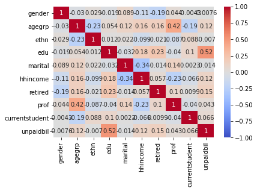

```python
import seaborn as sns
#https://heartbeat.fritz.ai/seaborn-heatmaps-13-ways-to-customize-correlation-matrix-visualizations-f1c49c816f07
#heatmap = df1[['fl_mean', 'fd_mean', 'fwb_mean', 'conf_mean', 'fin_sat_mean',  'fin_dep_mean']]

#f = plt.figure()
sns.heatmap(Features.corr(), annot = True, cmap = 'coolwarm', vmin=-1, vmax=1, center= 0)
```

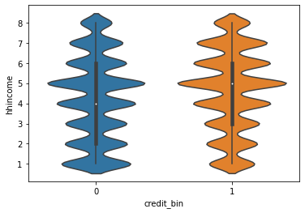

```python
ax = sns.violinplot(x=y, y='hhincome', data=df)
```

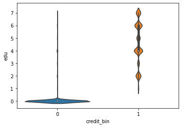

```python
ax = sns.violinplot(x=y, y='edu', data=df)
```

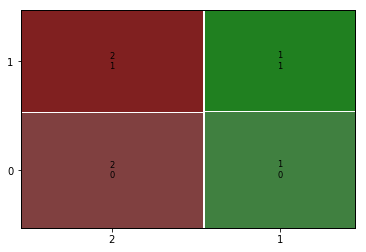

```python
from statsmodels.graphics.mosaicplot import mosaic
mosaic(df, ['gender', 'credit_bin'])
plt.show()
```

## Scaling Features

```python
X = StandardScaler().fit(Features).transform(Features)
X
```

```
array([[ 0.90883252,  0.79800063, -0.58910568, ...,  0.78819913,
        -0.16997002,  0.82464965],
       [ 0.90883252, -1.07243697, -0.58910568, ..., -0.80043509,
        -0.16997002,  0.82464965],
       [ 0.90883252, -1.07243697, -0.58910568, ..., -0.80043509,
        -0.16997002,  0.82464965],
       ...,
       [-1.10031274, -1.69591617, -0.58910568, ...,  1.18535769,
        -0.16997002, -1.48757615],
       [-1.10031274, -1.69591617,  1.69748829, ..., -0.80043509,
        -0.16997002, -1.48757615],
       [ 0.90883252,  1.42147982, -0.58910568, ..., -0.00611798,
        -0.16997002, -1.48757615]])
```

## Predicting Credit Card Behavior

### Logistics Regrression (Supervised Machine Learning)

```python
from sklearn.model_selection import train_test_split
X_train, X_test, y_train, y_test = train_test_split(X, y, test_size=0.2, random_state=0)
```

#### Create a Model and Train It

The below statement creates an instance of LogisticRegression and binds its references to the variable model. LogisticRegression has several optional parameters that define the behavior of the model and approach:

```python
from sklearn.linear_model import LogisticRegression
model = LogisticRegression(solver='liblinear', random_state=0)
```

```python
#model.fit(X, y)
model.fit(X_train, y_train)
```

```
LogisticRegression(random_state=0, solver='liblinear')
```

```python
y_predicted = model.predict(X_test) # needed for the confusion matrix
```

At this point, you have the classification model defined.

### Evaluate the Model

```python
#model.predict_proba(X)
#y_pred = model.predict(X_test)
#model.score(X_test,y_test)
print(cl('Logistic Regression Model Performace (%) :', 'red', attrs = ['bold']), round(lr.score(X_test,y_test) * 100, 2))
```

[output not shown]

.score() takes the input and output as arguments and returns the ratio of the number of correct predictions to the number of observations.

To create the confusion matrix, you can use confusion_matrix() and provide the actual and predicted outputs as the arguments:

```python
confusion_matrix(y_test, y_predicted)
```

```
array([[10703,   356],
       [  411,  9239]])
```

## Plot Confusion Matrix

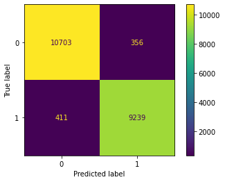

```python
metrics.plot_confusion_matrix(model, X_test, y_test)
plt.show()
```

**True negatives** in the upper-left position

**False negatives** in the lower-left position

**False positives** in the upper-right position

**True positives** in the lower-right position

The obtained matrix shows the following:

10703 true negative predictions: The first 10703 observations are zeros predicted correctly.

411 false negative predictions: These are the ones wrongly predicted as zeros.

356 false positive predictions: The observations are a zero that was wrongly predicted as one.

9239 true positive predictions: The last 9239 observations are ones predicted correctly.

In this figure, different colors represent different numbers and similar colors represent similar numbers. Heatmaps are a nice and convenient way to represent a matrix. To learn more about them, check out the Matplotlib documentation on Creating Annotated Heatmaps and .imshow().

To learn more about confusion matrix and logitc regression check out the [link](https://realpython.com/logistic-regression-python/#logistic-regression-in-python-with-scikit-learn-example-2)

```python
#results = model.fit()
#print(results.summary())
```

### Building the Same model with Decision Tree and comparing the performance of both

```python
#import requried libereries
from sklearn import tree

#Training your Model Decision Tree
dtree = tree.DecisionTreeClassifier()
dtree.fit(X_train, y_train)
y_predicted = dtree.predict(X_test)


#Training your Model Decision Tree
lr = LogisticRegression()
lr.fit(X_train,y_train)
lr_pred=lr.predict(X_test)


#Scoring your Model
print(cl('Decision Tree Model Performace (%) :', 'cyan', attrs = ['bold']), round(dtree.score(X_test,y_test) * 100, 2))
print(confusion_matrix(y_test, y_predicted))

print(cl('Logistic Regression Model Performace (%) :', 'magenta', attrs = ['bold']), round(lr.score(X_test,y_test) * 100, 2))
print(confusion_matrix(y_test, lr_pred))
```

```
Decision Tree Model Performace (%) : 96.61
[[10703   356]
 [  345  9305]]
Logistic Regression Model Performace (%) : 96.3
[[10703   356]
 [  411  9239]]
```

```python
from sklearn.neighbors import KNeighborsClassifier
from termcolor import colored as cl # elegant printing of text
from sklearn.metrics import accuracy_score # algorithm accuracy

#K nearest neighbors
classifier = KNeighborsClassifier(n_neighbors=5)
classifier.fit(X_train, y_train)
y_pred = classifier.predict(X_test)

#Print confusion matrix
print(cl('Prediction Accuracy Score (%) :', 'yellow', attrs = ['bold']), round(accuracy_score(y_test, y_pred) * 100, 2))
```

```
Prediction Accuracy Score (%) : 97.33
```

```python
#cm = confusion_matrix(y_test, y_pred)
print(cl('Confusion_Matrix:', 'green', attrs = ['bold']),
      confusion_matrix(y_test, y_pred))
```

```
Confusion_Matrix: [[10669   390]
 [  163  9487]]
```